# Bayesian Hierarchical Models with Stan

2019-05-05T00:00:00+01:00

# Bayesian Workflow with Stan

## What is Stan?

In this tutorial, we’ll walk through the basics of the Stan programming language. You can interface with Stan through almost any data analysis language (R, Python, shell, MATLAB, Julia, or Stata), but I will be interfacing with it in R.

Stan is an open-source software that uses No-U-Turn Hamiltonian Monte Carlo for Bayesian inference and is named after one of the creators of the Monte Carlo method, [Stanislaw Ulam](https://en.wikipedia.org/wiki/Stanislaw_Ulam).

## Interfacing with Stan through R

In order to use Stan, you need to install it. The process is fairly straightforward, but the steps vary slightly depending on your operation system. See [this help page](https://github.com/stan-dev/rstan/wiki/RStan-Getting-Started) for the details of installation.

Assuming you have a C++ compiler installed (follow the steps linked above), RStan can be installed by typing:

```r
install.packages("rstan",
                 repos = "https://cloud.r-project.org/",
                 dependencies = TRUE)
```

After installation, let’s load the RStan library.

```r
library(rstan)
```

## Stan Syntax

Stan requires the coding of your model in different blocks and in a specific order. In order, these blocks are data, transformed data, parameters, transformed parameters, model, and generated quantities. Let’s suppose that we wanted to estimate the following equation with Stan:

$$\begin{aligned}
y &\sim \text{Normal}(\mu, \sigma) \\
\mu &= \alpha + \beta x \\
\alpha &\sim \text{Normal}(0, 10) \\
\beta &\sim \text{Normal}(0, 10) \\
\sigma &\sim \text{Uniform}(0, 100) \\
\end{aligned}$$

A complete Stan program for this model looks like the following:

```stan
data { // This is the data block
  int N; // Specify Sample Size
  real y[N]; // A variable named y with length n
  real x[N]; // A variable named x with length n
}

transformed data {
  // this is where you could specify variable transformations
}

parameters { // Block for parameters to be estimated
  real a; // A parameter named a
  real b; // A parameter named b
  real sigma; // A parameter named sigma
}

transformed parameters {
  // Here you could specify transformations of your paramters
}

model {
  vector[N] mu; // create the linear predictor mu

  // Write the linear model
  for (i in 1:N) {
    mu[i] = a + b * x[i];
  }

  // Write out priors
  a ~ normal(0, 10);
  b ~ normal(0, 10);
  sigma ~ uniform(0, 100);

  // Write out the likelihood function
  for (i in 1:N) {
  y[i] ~ normal(mu[i], sigma);
  }
}

generated quantities {
  // Here you can calculate things like log-likelihood, replication data, etc.
}
```

After programming the model, you run the code which will tell R to compile it into a model. From there we are ready to sample from the model. Note that Stan is case sensitive and each line must terminate with a semi-colon “;”.

## Example!

### Exploratory Analysis

Let’s get going with an example using mpg data.

```r
mpg.data <- mpg

library(tidyverse)
glimpse(mpg)
```

```
## Observations: 234
## Variables: 11
## $ manufacturer <chr> "audi", "audi", "audi", "audi", "audi", "audi", "audi", …
## $ model        <chr> "a4", "a4", "a4", "a4", "a4", "a4", "a4", "a4 quattro", …
## $ displ        <dbl> 1.8, 1.8, 2.0, 2.0, 2.8, 2.8, 3.1, 1.8, 1.8, 2.0, 2.0, 2…
## $ year         <int> 1999, 1999, 2008, 2008, 1999, 1999, 2008, 1999, 1999, 20…
## $ cyl          <int> 4, 4, 4, 4, 6, 6, 6, 4, 4, 4, 4, 6, 6, 6, 6, 6, 6, 8, 8,…
## $ trans        <chr> "auto(l5)", "manual(m5)", "manual(m6)", "auto(av)", "aut…
## $ drv          <chr> "f", "f", "f", "f", "f", "f", "f", "4", "4", "4", "4", "…
## $ cty          <int> 18, 21, 20, 21, 16, 18, 18, 18, 16, 20, 19, 15, 17, 17, …
## $ hwy          <int> 29, 29, 31, 30, 26, 26, 27, 26, 25, 28, 27, 25, 25, 25, …
## $ fl           <chr> "p", "p", "p", "p", "p", "p", "p", "p", "p", "p", "p", "…
## $ class        <chr> "compact", "compact", "compact", "compact", "compact", "…
```

This data set contains data on the make and model over different cars along with their engine type, transmission type, and mpg. Let’s do some visualizations to get a better understanding of our data.

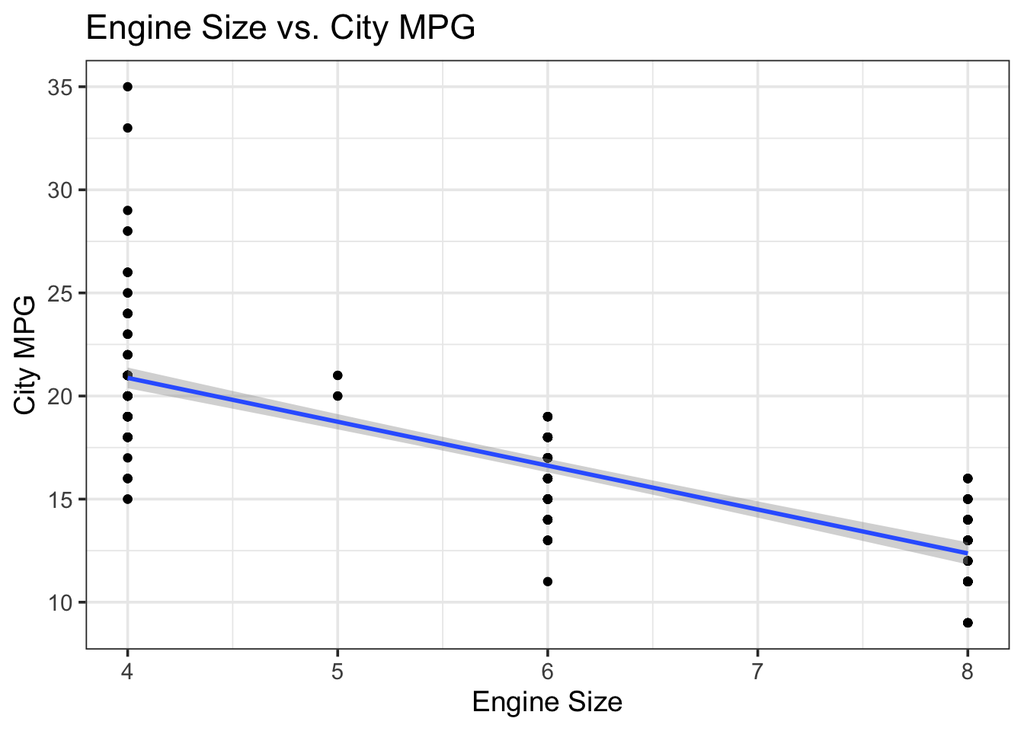

```r
ggplot(data = mpg.data,
       aes(x = cyl, y = cty)) +
  geom_point() +
  geom_smooth(method = "lm") +
  theme_bw(base_size = 14) +
  labs(x = "Engine Size",
       y = "City MPG",
       title = "Engine Size vs. City MPG")
```

As expected, there is a negative relationship between engine size and city MPG. Let’s build a simple linear model to see if engine type affects mpg. In mathematical notation, this model would look like:

$$\begin{aligned}
\text{mpg}_i &\sim \text{Normal}(\mu_i, \sigma) \\
\mu_i &= \alpha + \beta \cdot \text{Engine}_i \\
\alpha &\sim \text{Normal}(0, 100) \\
\beta &\sim \text{Normal}(0, 100) \\
\sigma &\sim \text{Uniform}(0, 100) \\
\end{aligned}$$

## Prior Simulations

Notice that I am specifying pretty uninformative priors. To see just how uninformative, let’s do some simulations. Centering continuous variables can also help to interpret priors.

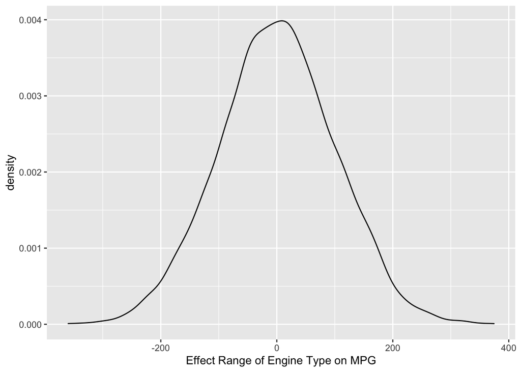

```r
# use rnorm to draw from a normal distribution
sim.data <- rnorm(n = 10000, mean = 0, sd = 100)

# convet the sim.data to a data frame (it's stored as a vector right now)
sim.data <- as.data.frame(sim.data)

# now let's plot it
ggplot() +
  geom_density(data = sim.data, aes(x = sim.data)) +
  # it's a good idea to label your axies to help you understand the units
  xlab("Effect Range of Engine Type on MPG")
```

So, we are telling the model that the average effect of engine type on MPG will be zero, but can range between a decrease of 200 and an increase of 200 MPG with reasonably high probability. Thus, this is a pretty flat prior. Cars with bigger engines will probably get lower MPG, but they probably don’t get 200 MPG lower! This is a good time to point out that uninformative priors are rarely ever a good idea since we almost always know something about the effects we are interested in before we estimate them.

Finally, let’s examine the prior for $\sigma$.

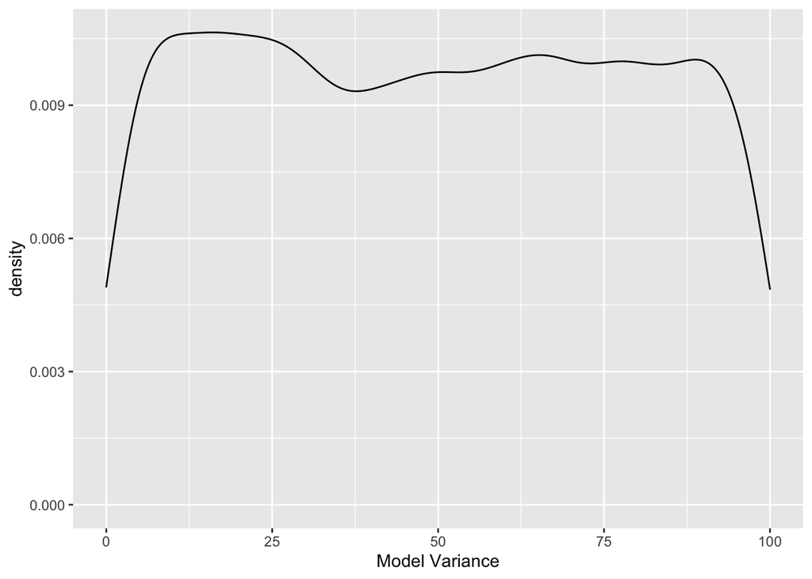

```r
# draw from a uniform distribution
sim.data <- runif(n = 10000, min = 0, max = 100)

# convert to a data from
sim.data <- as.data.frame(sim.data)

# now plot
ggplot() +
  geom_density(data = sim.data, aes(x = sim.data)) +
  xlab("Model Variance")
```

## Model Programming

Now that we know what we are telling the model *a priori*, let’s program the model. We’ll program it in three different ways to showcase the various options available in Stan. Also, when using Stan in R Markdown, you’ll want to assign each Stan program an output name. You can do this by specifying the `output.var =` in the code chunk options.

### Vectorized Syntax

```stan
data {
  int n; // number of observations (rows of data)
  vector[n] mpg; // variable called mpg as a vector of length n
  vector[n] engine; // variable called weight as a vector of length n
}

parameters {
  real alpha; // this will be our intercept
  real beta; // this will be our slope
  real sigma; // this will be our variance parameter
}

model {
  // create the linear predictor
  vector[n] mu;

  // write the linear combination
  mu = alpha + beta * engine;

  // priors
  alpha ~ normal(0, 100);
  beta ~ normal(0, 100);
  sigma ~ uniform(0, 100);

  // write the likelihood
  mpg ~ normal(mu, sigma);
}

generated quantities {
  vector[n] log_lik; // calculate log-likelihood
  vector[n] y_rep; // replications from posterior predictive distribution

  for (i in 1:n) {
    // generate mpg predicted value
    real mpg_hat = alpha + beta * engine[i];

    // calculate log-likelihood
    log_lik[i] = normal_lpdf(mpg[i] | mpg_hat, sigma);
    // normal_lpdf is the log of the normal probability densift function

    // generate replication values
    y_rep[i] = normal_rng(mpg_hat, sigma);
    // normal_rng generates random numbers from a normal distribution
  }
}
```

### Unvectorized Syntax

As an alternative to the vectorized syntax above, we could also program the model using unvectorized syntax. This is necessary with some types of models that don’t support vectorized notation. In general, the vectorized syntax is much more efficient. We’ll called this the unvectorized model `output.var = "unvec.model"`. Notice that with the unvectorized syntax, we tell the model what type of data our variables are. `mpg` and `engine` are real numbers.

```stan
data {
  int n; // number of observations (rows of data)
  real mpg[n]; // variable called mpg as a vector of length n
  real engine[n]; // variable called weight as a vector of length n
}

parameters {
  real alpha; // this will be our intercept
  real beta; // this will be our slope
  real sigma; // this will be our variance parameter
}

model {
  // create the linear predictor
  vector[n] mu;

  // write the linear combination
  for (i in 1:n) {
    mu[i] = alpha + beta * engine[i];
  }

  // priors
  alpha ~ normal(0, 100);
  beta ~ normal(0, 100);
  sigma ~ uniform(0, 100);

  // write the likelihood
  for (i in 1:n) {
    mpg[i] ~ normal(mu[i], sigma);
  }
}

generated quantities {
  vector[n] log_lik; // calculate log-likelihood
  vector[n] y_rep; // replications from posterior predictive distribution

  for (i in 1:n) {
    // generate mpg predicted value
    real mpg_hat = alpha + beta * engine[i];

    // calculate log-likelihood
    log_lik[i] = normal_lpdf(mpg[i] | mpg_hat, sigma);
    // normal_lpdf is the log of the normal probability densift function

    // generate replication values
    y_rep[i] = normal_rng(mpg_hat, sigma);
    // normal_rng generates random numbers from a normal distribution
  }
}
```

### Target+ Syntax

Finally, Stan allows users to directly specify the log-posterior using target+ syntax. Using this syntax, `y ~ normal(mu, sigma);` becomes `target += normal_lpdf(y | mu, sigma)`. This directly updates the target log density.

```stan
data {
  int n; // number of observations (rows of data)
  vector[n] mpg; // variable called mpg as a vector of length n
  vector[n] engine; // variable called weight as a vector of length n
}

parameters {
  real alpha; // this will be our intercept
  real beta; // this will be our slope
  real sigma; // this will be our variance parameter
}

model {
  // create the linear predictor
  vector[n] mu;

  // write the linear combination
  mu = alpha + beta * engine;

  target += normal_lpdf(alpha | 0, 100);
  target += normal_lpdf(beta | 0, 100);
  target += uniform_lpdf(sigma | 0, 100);
  target += normal_lpdf(mpg | mu, sigma);
}

generated quantities {
  vector[n] log_lik; // calculate log-likelihood
  vector[n] y_rep; // replications from posterior predictive distribution

  for (i in 1:n) {
    // generate mpg predicted value
    real mpg_hat = alpha + beta * engine[i];

    // calculate log-likelihood
    log_lik[i] = normal_lpdf(mpg[i] | mpg_hat, sigma);
    // normal_lpdf is the log of the normal probability densift function

    // generate replication values
    y_rep[i] = normal_rng(mpg_hat, sigma);
    // normal_rng generates random numbers from a normal distribution
  }
}
```

## Sampling

With the model programmed, we are ready to sample from it. We have to start by preparing the data. To prep the data we need to remove variables that we don’t need, convert the data to a list (Stan will not accept data frames), and generate a variable that tells us the number of observations. The `tidybayes` package is helpful for these tasks.

```r
# Prep Data -------------------------------------------------------------------
library(tidybayes)

# compose data
stan.data <-
  mpg.data %>%
  dplyr::select(cty, cyl) %>% # only select the variables we need
  rename(mpg = cty, # variable names must match our model program exactly
         engine = cyl) %>%
  mutate(engine = sjmisc::center(engine)) %>%
  # compose_data() coverts our data to a list and creates a sample size variable
  compose_data()

# Estimate Model --------------------------------------------------------------
vec.fit <- sampling(vec.model, # the model program
                    chains = 4, # we'll run 4 chains
                    iter = 500, # for 500 iterations
                    warmup = 100, # with 100 samples for the warmup period
                    data = stan.data) # using the stan.data list we created
# view the model results
print(vec.fit,
      pars = c("alpha", "beta", "sigma"),
      digits = 3,
      probs = c(0.055, 0.945)) # this give the 89% credible interval
```

```
## Inference for Stan model: 1eef64ab359afb4587c5ed3c589259e4.
## 4 chains, each with iter=500; warmup=100; thin=1;
## post-warmup draws per chain=400, total post-warmup draws=1600.
##
##         mean se_mean    sd   5.5%  94.5% n_eff  Rhat
## alpha 16.866   0.007 0.166 16.602 17.121   558 1.004
## beta  -2.125   0.002 0.100 -2.282 -1.970  1826 1.000
## sigma  2.537   0.003 0.115  2.358  2.726  1605 1.000
##
## Samples were drawn using NUTS(diag_e) at Thu Mar 26 14:44:14 2020.
## For each parameter, n_eff is a crude measure of effective sample size,
## and Rhat is the potential scale reduction factor on split chains (at
## convergence, Rhat=1).
```

```r
freq.fit <- lm(mpg ~ engine, data = as.data.frame(stan.data))
summary(freq.fit)
```

```
##
## Call:
## lm(formula = mpg ~ engine, data = as.data.frame(stan.data))
##
## Residuals:
##     Min      1Q  Median      3Q     Max
## -5.8785 -1.6225  0.1215  1.3775 14.1215
##
## Coefficients:
##             Estimate Std. Error t value Pr(>|t|)
## (Intercept)  16.8590     0.1651  102.10   <2e-16 ***
## engine       -2.1280     0.1027  -20.72   <2e-16 ***
## ---
## Signif. codes:  0 '***' 0.001 '**' 0.01 '*' 0.05 '.' 0.1 ' ' 1
##
## Residual standard error: 2.526 on 232 degrees of freedom
## Multiple R-squared:  0.6493, Adjusted R-squared:  0.6478
## F-statistic: 429.5 on 1 and 232 DF,  p-value: < 2.2e-16
```

## Convergence Diagnostics

After we fit the model, we need to make sure that our chains are mixing well. If they aren’t, the model will produce unreliable estimates. We can look at the R-hat values in the model summary or we could look at traceplots.

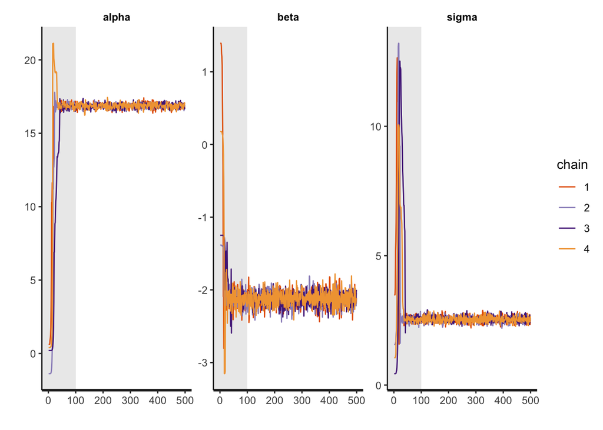

```r
traceplot(vec.fit, inc_warmup = 100, pars = c("alpha", "beta", "sigma"))
```

These plots show that the chains are well mixed, so our estimates should be reliable.

## Posterior Predictive Checks

To goal of posterior predictive checks is to compare the observed data with the data replicated from the model. A good model should be able to produce data that is very similar to the observed data. We’ll start by extracting the posterior predictive distribution.

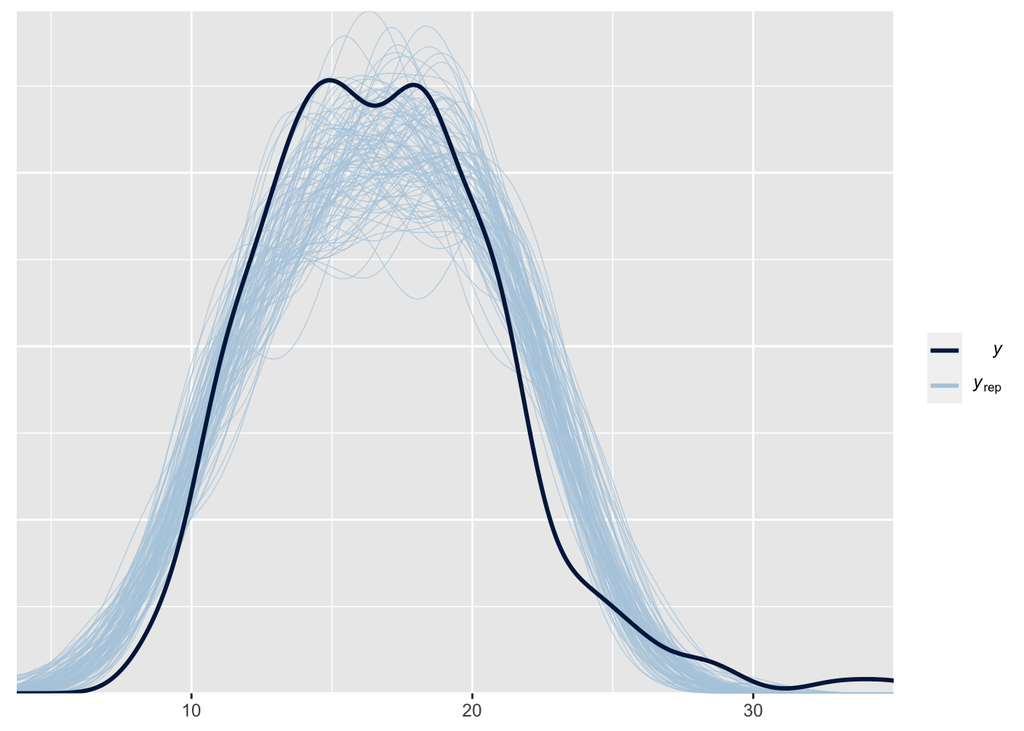

```r
library(bayesplot)
set.seed(1)

# get the observed outcome variable
y <- mpg$cty

# get the data produced by the model
yrep1 <- rstan::extract(vec.fit)[["y_rep"]]

# select 100 random samples from the generated data
samp100 <- sample(nrow(yrep1), 100)

# examine the observed vs. replicated data
ppc_dens_overlay(y, yrep = yrep1[samp100, ])
```